# EDA

2024-01-09

# EDA

```r
path <- here("data", "Data_SAS.xlsx")
data <- readxl::read_xlsx(path, sheet = 2)
#data %>% glimpse()
#data %>% summary()
```

## Приводим данные к нужному виду

```r
# Копируем исходный датафрейм
data_filtered <- data

# Переводим числовые столбцы в числовой формат
numeric_columns <- c("age", "disease duration", "THF dose", "gait", "arm dropping",
                          "shoulder shaking", "elbow rigidity", "wrist rigidity", "head rotation",
                          "glabella tap", "tremor", "salivation", "akathisia", "Total score SAS",
                          "P1", "P2", "P3", "P4", "P5", "P6", "P7", "Positive scale",
                          "N1", "N2", "N3", "N4", "N5", "N6", "N7", "Negative scale",
                          "G1", "G2", "G3", "G4", "G5", "G6", "G7", "G8", "G9", "G10",
                          "G11", "G12", "G13", "G14", "G15", "G16", "General Psychopathology scale",
                          "Total score PANSS", "Verbal Memory", "ZVM", "Digit Sequencing", "ZDS",
                          "Token Motor Task", "ZMT", "Verbal Fluency", "ZVF", "Symbol Coding", "ZSC",
                          "Tower of London", "ZToL", "Comp Z")

# все десятичные разделители делаем точками
data_filtered[numeric_columns] <- lapply(data_filtered[numeric_columns], function(x) {
  as.numeric(gsub(",", ".", x))
})

# Переводим категориальные столбцы в факторы
factor_columns <- c("gender", "visit", "antipsychotic","antipsychotic dose",
                    "course", "education", "smoke", "antipsychotic generation")

data_filtered[factor_columns] <- lapply(data_filtered[factor_columns], as_factor)

#data_filtered %>% glimpse
```

## Проверка шкал

Проверим, правильно ли посчитали SAS

```r
data_filtered %>%
  mutate(total_score_SAS_auto = rowSums(select(., gait:akathisia))) %>%
  filter(`Total score SAS` != total_score_SAS_auto)%>%
  select(id, `Total score SAS`, total_score_SAS_auto)
```

```
## # A tibble: 2 × 3
##   id    `Total score SAS` total_score_SAS_auto
##   <chr>             <dbl>                <dbl>
## 1 п14                   1                    2
## 2 п13                   8                    9
```

Выявлены ошибки в двух строках.

Проверим, правильно ли посчитали PANSS

```r
# Создаем колонки
data_compare <- data_filtered %>%
  mutate(
    Positive_scale_auto = rowSums(select(., P1:P7)),
    Negative_scale_auto = rowSums(select(., N1:N7)),
    General_Psychopathology_scale_auto = rowSums(select(., G1:G16)),
    Total_score_PANSS_auto = Positive_scale_auto + Negative_scale_auto + General_Psychopathology_scale_auto
  )

# Сравниваем
differences_pos_scale <- data_compare %>%
  filter(`Positive scale` != Positive_scale_auto)

differences_neg_scale <- data_compare %>%
  filter(`Negative scale` != Negative_scale_auto)

differences_gen_psychopathology <- data_compare %>%
  filter(`General Psychopathology scale` != General_Psychopathology_scale_auto)

differences_total_panss <- data_compare %>%
  filter(`Total score PANSS` != Total_score_PANSS_auto)
```

```
## Различия в Positive scale:
```

```
## # A tibble: 17 × 3
##    id    `Positive scale` Positive_scale_auto
##    <chr>            <dbl>               <dbl>
##  1 А11                  0                  14
##  2 А15                 18                  20
##  3 п14                  0                  15
##  4 п1                   0                  18
##  5 п14                  0                  11
##  6 А28                 23                  20
##  7 А8                   0                  14
##  8 А10                  0                  17
##  9 п13                  0                  14
## 10 п10                  0                  13
## 11 п11                  0                  13
## 12 А7                   0                  16
## 13 п12                  0                  16
## 14 п12                  0                  12
## 15 п9                   0                  12
## 16 А9                   0                  22
## 17 А29                 11                  12
```

```
##
## Различия в Negative scale:
```

```
## # A tibble: 20 × 3
##    id    `Negative scale` Negative_scale_auto
##    <chr>            <dbl>               <dbl>
##  1 А4                   0                  21
##  2 А6                   0                  20
##  3 А11                  0                  19
##  4 п14                  0                  19
##  5 п14                  0                  14
##  6 А8                   0                  22
##  7 А10                  0                  17
##  8 п13                  0                  20
##  9 п13                  0                  15
## 10 п10                  0                  20
## 11 п11                  0                  20
## 12 п10                  0                  15
## 13 п11                  0                  13
## 14 А7                   0                  20
## 15 п12                  0                  18
## 16 п12                  0                  14
## 17 п9                   0                  22
## 18 п9                   0                  15
## 19 А9                   0                  18
## 20 А27                 22                  23
```

```
##
## Различия в General Psychopathology scale:
```

```
## # A tibble: 22 × 3
##    id    `General Psychopathology scale` General_Psychopathology_scale_auto
##    <chr>                           <dbl>                              <dbl>
##  1 А4                                  0                                 40
##  2 А6                                  0                                 38
##  3 А11                                 0                                 35
##  4 п14                                 0                                 39
##  5 п1                                  0                                 39
##  6 п14                                 0                                 33
##  7 п21                                30                                 28
##  8 А8                                  0                                 42
##  9 А10                                 0                                 35
## 10 п13                                 0                                 42
## # ℹ 12 more rows
```

```
##
## Различия в Total score PANSS:
```

```
## # A tibble: 9 × 3
##   id    `Total score PANSS` Total_score_PANSS_auto
##   <chr>               <dbl>                  <dbl>
## 1 А15                    99                    101
## 2 А20                    50                     49
## 3 п21                    55                     53
## 4 А28                    91                     88
## 5 п33                    71                     61
## 6 п13                    63                     66
## 7 А9                     44                     59
## 8 А29                    60                     62
## 9 А27                    64                     65
```

Проверка шкалы BACS.

```r
# Код для автоматического расчета Z-баллов. Z-баллы рассчитывались с использованием норматимвных для российской популяции [Саркисян, Г. Р., Гурович, И. Я., & Киф, Р. С. (2010). Нормативные данные для российской популяции и стандартизация шкалы «Краткая оценка когнитивных функций у пациентов с шизофренией» (BACS). Социальная и клиническая психиатрия, 20 (3), 13-19.]

data_compare <- data_filtered %>%
  mutate(
    ZVM_auto = case_when(
      gender == 'м' & age < 30 ~ round((`Verbal Memory` - 49.55) / 7.1, 2),
      gender == 'м' & age > 29 & age < 40 ~ round((`Verbal Memory` - 48.67) / 7.1, 2),
      gender == 'м' & age > 39 & age < 50 ~ round((`Verbal Memory` - 44.44) / 5.47, 2),
      gender == 'ж' & age < 30 ~ round((`Verbal Memory` - 50.52) / 7.94, 2),
      gender == 'ж' & age > 29 & age < 40 ~ round((`Verbal Memory` - 49.77) / 7.25, 2),
      gender == 'ж' & age > 39 & age < 50 ~ round((`Verbal Memory` - 47.00) / 6.35, 2),
      gender == 'ж' & age > 49 & age < 60 ~ round((`Verbal Memory` - 44.33) / 7.32, 2),
      TRUE ~ NA_real_
    ),
    ZDS_auto = case_when(
      gender == 'м' & age < 30 ~ round((`Digit Sequencing` - 21.8) / 2.57, 2),
      gender == 'м' & age > 29 & age < 40 ~ round((`Digit Sequencing` - 22.14) / 3.35, 2),
      gender == 'м' & age > 39 & age < 50 ~ round((`Digit Sequencing` - 20.07) / 3.33, 2),
      gender == 'ж' & age < 30 ~ round((`Digit Sequencing` - 20.24) / 3.50, 2),
      gender == 'ж' & age > 29 & age < 40 ~ round((`Digit Sequencing` - 21.59) / 3.14, 2),
      gender == 'ж' & age > 39 & age < 50 ~ round((`Digit Sequencing` - 20.60) / 3.56, 2),
      gender == 'ж' & age > 49 & age < 60 ~ round((`Digit Sequencing` - 17.90) / 3.69, 2),
      TRUE ~ NA_real_
    ),
    ZMT_auto = case_when(
      gender == 'м' & age < 30 ~ round((`Token Motor Task` - 74.7) / 8.8, 2),
      gender == 'м' & age > 29 & age < 40 ~ round((`Token Motor Task` - 71.43) / 12.15, 2),
      gender == 'м' & age > 39 & age < 50 ~ round((`Token Motor Task` - 74.30) / 11.58, 2),
      gender == 'ж' & age < 30 ~ round((`Token Motor Task` - 68.57) / 9.36, 2),
      gender == 'ж' & age > 29 & age < 40 ~ round((`Token Motor Task` - 72.18) / 8.86, 2),
      gender == 'ж' & age > 39 & age < 50 ~ round((`Token Motor Task` - 71.6) / 12.64, 2),
      gender == 'ж' & age > 49 & age < 60 ~ round((`Token Motor Task` - 68.86) / 11.65, 2),
      TRUE ~ NA_real_
    ),
    ZVF_auto = case_when(
      gender == 'м' & age < 30 ~ round((`Verbal Fluency` - 58.4) / 9.46, 2),
      gender == 'м' & age > 29 & age < 40 ~ round((`Verbal Fluency` - 56.48) / 14.04, 2),
      gender == 'м' & age > 39 & age < 50 ~ round((`Verbal Fluency` - 62.00) / 16.76, 2),
      gender == 'ж' & age < 30 ~ round((`Verbal Fluency` - 54.8) / 14.53, 2),
      gender == 'ж' & age > 29 & age < 40 ~ round((`Verbal Fluency` - 60.45) / 11.05, 2),
      gender == 'ж' & age > 39 & age < 50 ~ round((`Verbal Fluency` - 58.2) / 10.7, 2),
      gender == 'ж' & age > 49 & age < 60 ~ round((`Verbal Fluency` - 58.29) / 10.79, 2),
      TRUE ~ NA_real_
    ),
    ZSC_auto = case_when(
      gender == 'м' & age < 30 ~ round((`Symbol Coding` - 61.95) / 8.06, 2),
      gender == 'м' & age > 29 & age < 40 ~ round((`Symbol Coding` - 61.24) / 10.73, 2),
      gender == 'м' & age > 39 & age < 50 ~ round((`Symbol Coding` - 54.35) / 6.61, 2),
      gender == 'ж' & age < 30 ~ round((`Symbol Coding` - 65.71) / 6.09, 2),
      gender == 'ж' & age > 29 & age < 40 ~ round((`Symbol Coding` - 60.86) / 8.74, 2),
      gender == 'ж' & age > 39 & age < 50 ~ round((`Symbol Coding` - 57.4) / 7.55, 2),
      gender == 'ж' & age > 49 & age < 60 ~ round((`Symbol Coding` - 50.1) / 10.24, 2),
      TRUE ~ NA_real_
    ),
    ZToL_auto = case_when(
      gender == 'м' & age < 30 ~ round((`Tower of London` - 18.45) / 1.82, 2),
      gender == 'м' & age > 29 & age < 40 ~ round((`Tower of London` - 19.1) / 1.67, 2),
      gender == 'м' & age > 39 & age < 50 ~ round((`Tower of London` - 18.35) / 2.98, 2),
      gender == 'ж' & age < 30 ~ round((`Tower of London` - 17.67) / 1.93, 2),
      gender == 'ж' & age > 29 & age < 40 ~ round((`Tower of London` - 17.64) / 1.71, 2),
      gender == 'ж' & age > 39 & age < 50 ~ round((`Tower of London` - 17.4) / 1.76, 2),
      gender == 'ж' & age > 49 & age < 60 ~ round((`Tower of London` - 16.48) / 2.36, 2),
      TRUE ~ NA_real_
    )
  )

data_compare <- data_compare %>% mutate(
  Comp_Z_auto = round(rowSums(select(., ZVM_auto:ZToL_auto))/ 3.96, 2))
```

```r
# Сравниваем
differences_ZVM <- data_compare %>%
  filter(ZVM_auto != ZVM)

differences_ZDS <- data_compare %>%
  filter(ZDS_auto != ZDS)

differences_ZMT <- data_compare %>%
  filter(ZMT_auto != ZMT)

differences_ZVF <- data_compare %>%
  filter(ZVF_auto != ZVF)

differences_ZSC <- data_compare %>%
  filter(ZSC_auto != ZSC)

differences_ZToL <- data_compare %>%
  filter(ZToL_auto != ZToL)

differences_Comp_Z <- data_compare %>%
  filter(Comp_Z_auto != `Comp Z`)
```

```
## Различия в ZVM:
```

```
## # A tibble: 108 × 3
##    id       ZVM ZVM_auto
##    <chr>  <dbl>    <dbl>
##  1 А3     -9.38    -0.32
##  2 А4    -10.9     -2.19
##  3 А6    -10.5     -0.78
##  4 А11   -11.0     -2.47
##  5 А15    -9.48    -3.15
##  6 А18    -9.44    -0.57
##  7 А20    -9.02    -2.07
##  8 А30    -9.02    -2.07
##  9 п1     -8.88    -4.47
## 10 п14   -10.7     -1.32
## # ℹ 98 more rows
```

```
##
## Различия в ZDS:
```

```
## # A tibble: 108 × 3
##    id       ZDS ZDS_auto
##    <chr>  <dbl>    <dbl>
##  1 А3     -9.82    -1.5
##  2 А4    -10.5     -2.26
##  3 А6    -10.2     -1.09
##  4 А11   -10.6     -2.65
##  5 А15   -10.3     -4.66
##  6 А18    -9.75    -1.21
##  7 А20    -9.25    -2.73
##  8 А30    -8.27     1.15
##  9 п1     -8.44    -0.62
## 10 п14   -10.7     -1.78
## # ℹ 98 more rows
```

```
##
## Различия в ZMT:
```

```
## # A tibble: 108 × 3
##    id       ZMT ZMT_auto
##    <chr>  <dbl>    <dbl>
##  1 А3     -9.4     -1.34
##  2 А4     -9.87     0.37
##  3 А6    -10.3     -1.44
##  4 А11   -10.4     -1.9
##  5 А15    -9.03     0.35
##  6 А18    -8.75     1.22
##  7 А20    -8.4      1.36
##  8 А30    -8.82    -0.28
##  9 п1     -8.34    -0.63
## 10 п14   -10.9     -2.84
## # ℹ 98 more rows
```

```
##
## Различия в ZVF:
```

```
## # A tibble: 108 × 3
##    id       ZVF ZVF_auto
##    <chr>  <dbl>    <dbl>
##  1 А3     -9.86     0.36
##  2 А4    -10.9     -1.31
##  3 А6    -10.6     -0.36
##  4 А11   -10.7     -0.47
##  5 А15    -9.82    -2.54
##  6 А18    -9.95     0.01
##  7 А20    -8.99     0.89
##  8 А30    -9.4     -0.75
##  9 п1     -9.28    -1.61
## 10 п14   -11.6     -2.33
## # ℹ 98 more rows
```

```
## Различия в ZSC:
```

```
## # A tibble: 108 × 3
##    id       ZSC ZSC_auto
##    <chr>  <dbl>    <dbl>
##  1 А3     -8.13     0.21
##  2 А4    -10.6     -1.73
##  3 А6    -10.2     -0.24
##  4 А11   -10.5     -1.48
##  5 А15    -9.38    -2.97
##  6 А18    -9.25    -4.22
##  7 А20    -9.15    -1.42
##  8 А30    -8.96    -0.67
##  9 п1     -8.43    -2.78
## 10 п14   -10.6     -2.91
## # ℹ 98 more rows
```

```
## Различия в ZToL:
```

```
## # A tibble: 108 × 3
##    id     ZToL ZToL_auto
##    <chr> <dbl>     <dbl>
##  1 А3    -8.03      2.24
##  2 А4    -9.61     -0.25
##  3 А6    -9.19      1.4
##  4 А11   -9.61     -0.25
##  5 А15   -9.12     -4.2
##  6 А18   -8.94     -1.38
##  7 А20   -6.9       1.74
##  8 А30   -7.36     -0.06
##  9 п1    -8.2       0.22
## 10 п14   -9.06      2.24
## # ℹ 98 more rows
```

```
## Различия в Comp Z:
```

```
## # A tibble: 70 × 3
##    id    `Comp Z` Comp_Z_auto
##    <chr>    <dbl>       <dbl>
##  1 А4       -1.42       -1.86
##  2 А6       -0.27       -0.63
##  3 А11      -1.87       -2.33
##  4 А15      -4.41       -4.34
##  5 А20      -0.53       -0.56
##  6 А30      -0.59       -0.68
##  7 п1       -3.01       -2.5
##  8 п14      -2.99       -2.26
##  9 А4       -0.06       -0.54
## 10 А6        0.32       -0.06
## # ℹ 60 more rows
```

Выявлены ошибки в Total score SAS, Positive scale, Negative scale, General Psychopathology scale, Total score PANSS. Так же выявлены ошибки во всех BACS.

## Исправление ошибок

Для замены данных правильными, создан скрипт preprocessing.R:

- Исправиляет найденные ошибки в шкалах.
- Добавляет 5-факторную модель.
- Добавляет хлорпромазиновый эквивалент.
- Создает Data_SAS_fixed.xlsx в _misc.

```r
path <- here("scripts/0_preprocessing", "preprocessing.R")
source(path)
path <- here("data", "Data_SAS.xlsx")
data_filtered <- preprocessing(path)
```

## EDA - исправленные данные

```r
# data_filtered %>%
# glimpse()
# data_filtered %>% colnames()
```

```r
data_filtered %>%
  select("gender", "age", "disease duration", "antipsychotic dose", "antipsychotic generation", "THF dose", "course", "education", "smoke", "Total score SAS", "Total score PANSS", "Comp Z", "CPZE") %>%
  describe() %>%
  select(vars, n, mean, sd, median, min, max, range) %>%
  kable("html") %>%
  kable_styling("striped", full_width = FALSE)
```

|  | vars | n | mean | sd | median | min | max | range |
| --- | --- | --- | --- | --- | --- | --- | --- | --- |
| gender* | 1 | 108 | 1.518519 | 0.5019864 | 2.00 | 1.00 | 2.00 | 1.00 |
| age | 2 | 108 | 30.666667 | 8.5816583 | 31.00 | 18.00 | 51.00 | 33.00 |
| disease duration | 3 | 108 | 9.037037 | 6.5194546 | 8.00 | 1.00 | 32.00 | 31.00 |
| antipsychotic dose* | 4 | 108 | 9.185185 | 3.9627899 | 10.00 | 1.00 | 18.00 | 17.00 |
| antipsychotic generation* | 5 | 108 | 2.166667 | 0.7913079 | 2.00 | 1.00 | 3.00 | 2.00 |
| THF dose | 6 | 108 | 3.444444 | 2.6345417 | 4.00 | 0.00 | 12.00 | 12.00 |
| course* | 7 | 108 | 2.166667 | 1.2035772 | 2.00 | 1.00 | 4.00 | 3.00 |
| education* | 8 | 108 | 2.518518 | 1.3076445 | 2.50 | 1.00 | 4.00 | 3.00 |
| smoke* | 9 | 108 | 1.314815 | 0.4666073 | 1.00 | 1.00 | 2.00 | 1.00 |
| Total score SAS | 10 | 108 | 5.500000 | 3.5769250 | 5.00 | 0.00 | 16.00 | 16.00 |
| Total score PANSS | 11 | 108 | 70.296296 | 17.0437915 | 69.00 | 36.00 | 122.00 | 86.00 |
| Comp Z | 12 | 108 | 46.042407 | 9.8516201 | 47.87 | 14.19 | 62.18 | 47.99 |
| CPZE | 13 | 108 | 3.725000 | 2.7856735 | 3.00 | 0.38 | 11.24 | 10.86 |

```r
data_filtered %>%
  select("gender", "age", "disease duration", "antipsychotic dose", "antipsychotic generation", "THF dose", "course", "education", "smoke", "visit", "Total score SAS", "Total score PANSS", "Comp Z", "CPZE") %>%
  summary() %>%
  kable("html") %>%
  kable_styling("striped", full_width = FALSE)
```

|  | gender | age | disease duration | antipsychotic dose | antipsychotic generation | THF dose | course | education | smoke | visit | Total score SAS | Total score PANSS | Comp Z | CPZE |
| --- | --- | --- | --- | --- | --- | --- | --- | --- | --- | --- | --- | --- | --- | --- |
|  | ж:52 | Min. :18.00 | Min. : 1.000 | 30 :20 | 1:26 | Min. : 0.000 | непрерывный :46 | высшее :38 | 0:74 | 1:54 | Min. : 0.0 | Min. : 36.0 | Min. :14.19 | Min. : 0.380 |
|  | м:56 | 1st Qu.:24.00 | 1st Qu.: 4.000 | 20 :14 | 2:38 | 1st Qu.: 2.000 | эпизодический ремиттирующий :22 | незаконченное высшее :16 | 1:34 | 2:54 | 1st Qu.: 3.0 | 1st Qu.: 58.0 | 1st Qu.:39.54 | 1st Qu.: 2.000 |
|  | NA | Median :31.00 | Median : 8.000 | 6 :10 | 3:44 | Median : 4.000 | эпизодический тип со стабильным дефектом:16 | среднее общее :14 | NA | NA | Median : 5.0 | Median : 69.0 | Median :47.87 | Median : 3.000 |
|  | NA | Mean :30.67 | Mean : 9.037 | 10 :10 | NA | Mean : 3.444 | эпизодическое с нарастающим дефектом :24 | среднее профессиональное:40 | NA | NA | Mean : 5.5 | Mean : 70.3 | Mean :46.04 | Mean : 3.725 |
|  | NA | 3rd Qu.:36.00 | 3rd Qu.:13.000 | 15 :10 | NA | 3rd Qu.: 4.000 | NA | NA | NA | NA | 3rd Qu.: 8.0 | 3rd Qu.: 80.0 | 3rd Qu.:53.11 | 3rd Qu.: 4.500 |
|  | NA | Max. :51.00 | Max. :32.000 | 4.5 : 8 | NA | Max. :12.000 | NA | NA | NA | NA | Max. :16.0 | Max. :122.0 | Max. :62.18 | Max. :11.240 |
|  | NA | NA | NA | (Other):36 | NA | NA | NA | NA | NA | NA | NA | NA | NA | NA |

EDA с помощью Shiny

```r
path <- here("scripts/1_eda", "eda_shiny_func.R")
source(path)
eda_shiny(data_filtered)
```

# Динамика

Исследуем изменение количественных переменных между визитами используя:

```r
# Указываем переменные, для которых хотим провести t-тест
selected_variables <- data_filtered %>% select_if(is.numeric) %>% names()

# Проводим t-тест и тест на нормальность для каждой переменной
alpha = 0.05  # Устанавливаем уровень значимости
test_results <- lapply(selected_variables, function(variable) {
  # Проводим тест на нормальность
  normality_test_result <- shapiro.test(data_filtered[[variable]])

  # Проводим t-тест независимо от результата теста на нормальность
  visit_1 <- data_filtered %>%
    filter(visit == 1) %>%
    pull(variable)
  visit_2 <- data_filtered %>%
    filter(visit == 2) %>%
    pull(variable)
  test_result <- t.test(visit_1, visit_2, paired=TRUE)

  # Собираем результаты в data frame
  result_df <- data.frame(
    Variable = variable,
    t_value = test_result$statistic,
    t_p_value = test_result$p.value,
    t_significant_flag = ifelse(test_result$p.value < alpha, "1", "0"),
    normality_p_value = normality_test_result$p.value,
    normality_result = ifelse(normality_test_result$p.value > 0.05, "Normal", "Not normal")
  )
  return(result_df)
})

# Объединяем результаты
test_results <- bind_rows(test_results)

# Добавляем тест Уилкоксона к результатам
wilcoxon_test_result <- lapply(selected_variables, function(variable) {
  wilcoxon_result <- wilcox.test(data_filtered[[variable]] ~ data_filtered$visit)
  result_df <- data.frame(
    Variable = variable,
    wilcoxon_statistic = wilcoxon_result$statistic,
    wilcoxon_p_value = wilcoxon_result$p.value,
    wilcoxon_significant_flag = ifelse(wilcoxon_result$p.value < alpha, "1", "0")
  )
  return(result_df)
})

# Объединяем результаты Уилкоксона с предыдущими результатами
wilcoxon_test_result <- bind_rows(wilcoxon_test_result)
test_results <- left_join(test_results, wilcoxon_test_result, by = "Variable")

# Выводим результаты
test_results %>%
  kable(format = "html") %>%
  kable_styling("striped", full_width = FALSE)
```

| Variable | t_value | t_p_value | t_significant_flag | normality_p_value | normality_result | wilcoxon_statistic | wilcoxon_p_value | wilcoxon_significant_flag |
| --- | --- | --- | --- | --- | --- | --- | --- | --- |
| age | NaN | NaN | NA | 0.0025281 | Not normal | 1458.0 | 1.0000000 | 0 |
| disease duration | NaN | NaN | NA | 0.0000012 | Not normal | 1458.0 | 1.0000000 | 0 |
| THF dose | NaN | NaN | NA | 0.0000000 | Not normal | 1458.0 | 1.0000000 | 0 |
| arm dropping | 3.1099088 | 0.0030100 | 1 | 0.0000000 | Not normal | 1658.0 | 0.1544698 | 0 |
| shoulder shaking | 1.3518825 | 0.1821542 | 0 | 0.0000000 | Not normal | 1552.0 | 0.5143361 | 0 |
| elbow rigidity | 0.7716901 | 0.4437252 | 0 | 0.0000000 | Not normal | 1465.5 | 0.9619043 | 0 |
| wrist rigidity | 0.0000000 | 1.0000000 | 0 | 0.0000000 | Not normal | 1458.0 | 1.0000000 | 0 |
| head rotation | 1.6278821 | 0.1094809 | 0 | 0.0000000 | Not normal | 1569.0 | 0.3761511 | 0 |
| glabella tap | 0.1840267 | 0.8546948 | 0 | 0.0000000 | Not normal | 1454.0 | 0.9803432 | 0 |
| tremor | 0.3891382 | 0.6987330 | 0 | 0.0000000 | Not normal | 1480.0 | 0.8866216 | 0 |
| salivation | 1.7287257 | 0.0896802 | 0 | 0.0000000 | Not normal | 1570.0 | 0.4436337 | 0 |
| akathisia | 3.0360157 | 0.0037123 | 1 | 0.0000000 | Not normal | 1709.0 | 0.0311725 | 1 |
| Total score SAS | 3.3528516 | 0.0014820 | 1 | 0.0002253 | Not normal | 1680.5 | 0.1701404 | 0 |
| Positive scale | 12.9030900 | 0.0000000 | 1 | 0.0001828 | Not normal | 2420.0 | 0.0000000 | 1 |
| Negative scale | 14.3717866 | 0.0000000 | 1 | 0.0476324 | Not normal | 2535.5 | 0.0000000 | 1 |
| General Psychopathology scale | 15.0638747 | 0.0000000 | 1 | 0.0003330 | Not normal | 2574.0 | 0.0000000 | 1 |
| Total score PANSS | 19.3645682 | 0.0000000 | 1 | 0.0025569 | Not normal | 2651.0 | 0.0000000 | 1 |
| Verbal Memory | -1.8670719 | 0.0674267 | 0 | 0.2436836 | Normal | 1298.0 | 0.3266137 | 0 |
| ZVM | -1.9083220 | 0.0617724 | 0 | 0.2185058 | Normal | 1289.5 | 0.3018620 | 0 |
| Digit Sequencing | -0.2130582 | 0.8320990 | 0 | 0.0449040 | Not normal | 1439.0 | 0.9091783 | 0 |
| ZDS | -0.2320056 | 0.8174272 | 0 | 0.6193711 | Normal | 1446.5 | 0.9460956 | 0 |
| Token Motor Task | -3.0680451 | 0.0033909 | 1 | 0.0337682 | Not normal | 1132.0 | 0.0452132 | 1 |
| ZMT | -3.2234304 | 0.0021694 | 1 | 0.0145899 | Not normal | 1172.0 | 0.0793181 | 0 |
| Verbal Fluency | -0.7690813 | 0.4452590 | 0 | 0.0680767 | Normal | 1403.0 | 0.7376155 | 0 |
| ZVF | -0.6892374 | 0.4936805 | 0 | 0.0953236 | Normal | 1385.5 | 0.6581747 | 0 |
| Symbol Coding | -2.4264228 | 0.0186832 | 1 | 0.3020711 | Normal | 1259.0 | 0.2222861 | 0 |
| ZSC | -2.4442973 | 0.0178735 | 1 | 0.1198517 | Normal | 1281.5 | 0.2794418 | 0 |
| Tower of London | -2.3506450 | 0.0224944 | 1 | 0.0000502 | Not normal | 1320.5 | 0.3954908 | 0 |
| ZToL | -2.1603754 | 0.0352848 | 1 | 0.0000278 | Not normal | 1337.5 | 0.4606366 | 0 |
| Comp Z | -3.4109538 | 0.0012458 | 1 | 0.0013738 | Not normal | 1223.0 | 0.1496179 | 0 |
| negative | 13.2386254 | 0.0000000 | 1 | 0.0152730 | Not normal | 2539.5 | 0.0000000 | 1 |
| excitment | 10.4596209 | 0.0000000 | 1 | 0.0000008 | Not normal | 2173.5 | 0.0000095 | 1 |
| cognitive | 10.4099993 | 0.0000000 | 1 | 0.0073525 | Not normal | 2503.5 | 0.0000000 | 1 |
| positive | 10.2887452 | 0.0000000 | 1 | 0.0017000 | Not normal | 2289.0 | 0.0000003 | 1 |
| depression | 11.8603041 | 0.0000000 | 1 | 0.0010265 | Not normal | 2504.5 | 0.0000000 | 1 |
| CPZE | NaN | NaN | NA | 0.0000000 | Not normal | 1458.0 | 1.0000000 | 0 |

Только значимые:

```r
significant_variables <- test_results %>%
  filter(t_significant_flag == 1 | wilcoxon_significant_flag == 1)
significant_variables %>%
  select(Variable, t_significant_flag, wilcoxon_significant_flag, normality_result) %>%
  kable(format = "html") %>%
  kable_styling("striped", full_width = FALSE)
```

| Variable | t_significant_flag | wilcoxon_significant_flag | normality_result |
| --- | --- | --- | --- |
| arm dropping | 1 | 0 | Not normal |
| akathisia | 1 | 1 | Not normal |
| Total score SAS | 1 | 0 | Not normal |
| Positive scale | 1 | 1 | Not normal |
| Negative scale | 1 | 1 | Not normal |
| General Psychopathology scale | 1 | 1 | Not normal |
| Total score PANSS | 1 | 1 | Not normal |
| Token Motor Task | 1 | 1 | Not normal |
| ZMT | 1 | 0 | Not normal |
| Symbol Coding | 1 | 0 | Normal |
| ZSC | 1 | 0 | Normal |
| Tower of London | 1 | 0 | Not normal |
| ZToL | 1 | 0 | Not normal |
| Comp Z | 1 | 0 | Not normal |
| negative | 1 | 1 | Not normal |
| excitment | 1 | 1 | Not normal |
| cognitive | 1 | 1 | Not normal |
| positive | 1 | 1 | Not normal |
| depression | 1 | 1 | Not normal |

Создадим датафрейм, содержащие разницу количественных показателей между визитами. Для этого используем make_difference_df.R

```r
path <- here("scripts/0_preprocessing", "make_difference_df.R")
source(path)
difference_df <- make_dif_df(data_filtered)
difference_df
```

```
## # A tibble: 54 × 54
##    id      age `disease duration` `THF dose` gait_dif `arm dropping_dif`
##    <chr> <dbl>              <dbl>      <dbl>    <dbl>              <dbl>
##  1 N26      18                  4          4       -1                 -1
##  2 N27      21                  8          0        0                  0
##  3 А1       19                  7          4        0                  0
##  4 А10      18                  3          2        0                  0
##  5 А11      44                  3          0        0                 -1
##  6 А12      27                 16          4        0                  0
##  7 А13      34                  9          2       -1                  0
##  8 А14      34                 11          4        0                 -1
##  9 А15      40                 14          4        0                  0
## 10 А16      19                  1          0        0                  0
## # ℹ 44 more rows
## # ℹ 48 more variables: `shoulder shaking_dif` <dbl>,
## #   `elbow rigidity_dif` <dbl>, `wrist rigidity_dif` <dbl>,
## #   `head rotation_dif` <dbl>, `glabella tap_dif` <dbl>, tremor_dif <dbl>,
## #   salivation_dif <dbl>, akathisia_dif <dbl>, `Total score SAS_dif` <dbl>,
## #   `Positive scale_dif` <dbl>, `Negative scale_dif` <dbl>, G1_dif <dbl>,
## #   G2_dif <dbl>, G3_dif <dbl>, G4_dif <dbl>, G5_dif <dbl>, G6_dif <dbl>, …
```

Визуализируем:

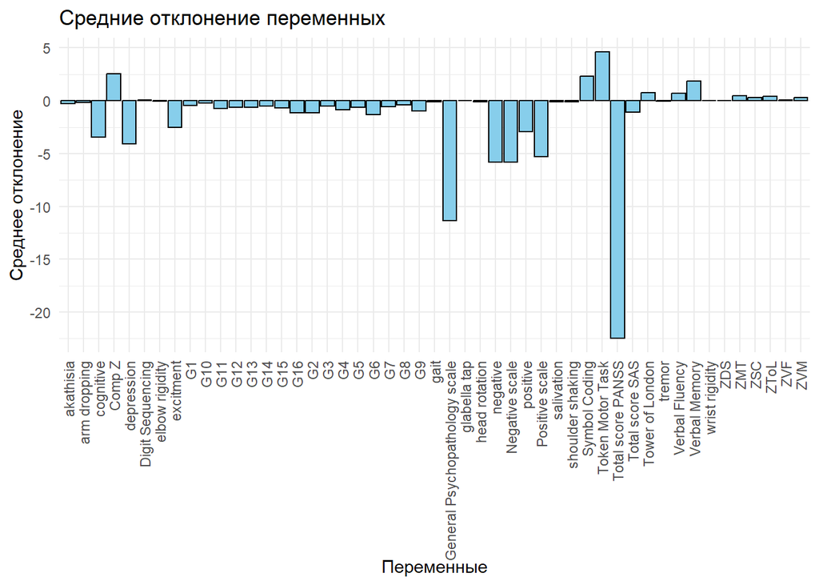

```r
difference_df %>%
  gather(variable, value, -id) %>%
  group_by(variable) %>%
  summarise(mean_value = mean(value, na.rm = TRUE)) %>%
  filter(grepl("_dif$", variable)) %>%
  mutate(variable = gsub("_dif$", "", variable)) %>%
  ggplot(aes(x = variable, y = mean_value)) +
  geom_bar(stat = "identity", fill = "skyblue", color = "black") +
  labs(title = "Средние отклонение переменных",
       x = "Переменные",
       y = "Среднее отклонение") +
  theme_minimal() +
  theme(axis.text.x = element_text(angle = 90, vjust = 0.5, hjust = 1))
```

Тоже самое более кратко.

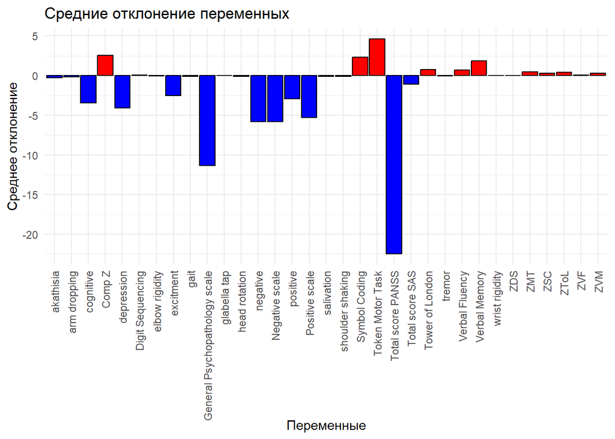

```r
difference_df %>%
  gather(variable, value, -id) %>%
  filter(!grepl("G[1-9]|N[1-7]|P[1-7]_dif$", variable)) %>%
  group_by(variable) %>%
  summarise(mean_value = mean(value, na.rm = TRUE)) %>%
  filter(grepl("_dif$", variable)) %>%
  mutate(variable = gsub("_dif$", "", variable)) %>%
  ggplot(aes(x = variable, y = mean_value, fill = factor(sign(mean_value)))) +
  geom_bar(stat = "identity", color = "black") +
  scale_fill_manual(values = c("blue", "gray", "red"), name = "Знак", labels = c("Отрицательное", "Ноль", "Положительное")) +
  labs(title = "Средние отклонение переменных",
       x = "Переменные",
       y = "Среднее отклонение") +
  theme_minimal() +
  guides(fill = FALSE) +
  theme(axis.text.x = element_text(angle = 90, vjust = 0.5, hjust = 1))
```

EDA difference_df в shiny доступна только для числовых переменнных.

Доступна только вкладка “Числовые переменные” без разбития по visit.

```r
path <- here("scripts/1_eda", "eda_shiny_func.R")
source(path)
eda_shiny(difference_df)
```

## Строим модель

### Первые модели

Простая модель, включающая только `Total score SAS_dif`, `Total score PANSS_dif`. Предсказываем `Comp Z_dif`

```r
lm(`Comp Z_dif` ~ `Total score SAS_dif` + `Total score PANSS_dif`, data=difference_df) %>%
  summary()
```

```
##
## Call:
## lm(formula = `Comp Z_dif` ~ `Total score SAS_dif` + `Total score PANSS_dif`,
##     data = difference_df)
##
## Residuals:
##      Min       1Q   Median       3Q      Max
## -11.5027  -2.7584   0.2366   2.7017  13.5278
##
## Coefficients:
##                           Estimate Std. Error t value Pr(>|t|)
## (Intercept)              1.9181162  2.1432363   0.895   0.3750
## `Total score SAS_dif`   -0.5582203  0.3150935  -1.772   0.0824 .
## `Total score PANSS_dif` -0.0002347  0.0869445  -0.003   0.9979
## ---
## Signif. codes:  0 '***' 0.001 '**' 0.01 '*' 0.05 '.' 0.1 ' ' 1
##
## Residual standard error: 5.377 on 51 degrees of freedom
## Multiple R-squared:  0.05843,    Adjusted R-squared:  0.02151
## F-statistic: 1.583 on 2 and 51 DF,  p-value: 0.2154
```

Модель получается лучше, если оставить только `Total score SAS_dif`

```r
lm(`Comp Z_dif` ~ `Total score SAS_dif`, data=difference_df) %>%
  summary()
```

```
##
## Call:
## lm(formula = `Comp Z_dif` ~ `Total score SAS_dif`, data = difference_df)
##
## Residuals:
##      Min       1Q   Median       3Q      Max
## -11.5042  -2.7610   0.2371   2.7036  13.5284
##
## Coefficients:
##                       Estimate Std. Error t value Pr(>|t|)
## (Intercept)             1.9235     0.7978   2.411   0.0195 *
## `Total score SAS_dif`  -0.5581     0.3107  -1.796   0.0782 .
## ---
## Signif. codes:  0 '***' 0.001 '**' 0.01 '*' 0.05 '.' 0.1 ' ' 1
##
## Residual standard error: 5.325 on 52 degrees of freedom
## Multiple R-squared:  0.05843,    Adjusted R-squared:  0.04033
## F-statistic: 3.227 on 1 and 52 DF,  p-value: 0.07824
```

Теперь попробуем построить сложную модель, пусть функция step разбирается. Установим trace=0, чтобы увидеть только последнюю модель.

```r
# уберем линейно зависимые переменные
selected_data <- difference_df %>%
  select(-id, -excitment_dif, -cognitive_dif, -depression_dif ,
         -starts_with('N'), -starts_with('P'), -starts_with('G'), -starts_with('Z'))
lm(`Comp Z_dif` ~ ., data=selected_data) %>%
  step(trace=0) %>%
  summary()
```

```
##
## Call:
## lm(formula = `Comp Z_dif` ~ age + `elbow rigidity_dif` + `wrist rigidity_dif` +
##     akathisia_dif + `Total score PANSS_dif` + `Verbal Memory_dif` +
##     `Digit Sequencing_dif` + `Token Motor Task_dif` + `Verbal Fluency_dif` +
##     `Symbol Coding_dif` + `Tower of London_dif`, data = selected_data)
##
## Residuals:
##      Min       1Q   Median       3Q      Max
## -0.21602 -0.05717  0.01222  0.04605  0.15978
##
## Coefficients:
##                          Estimate Std. Error t value Pr(>|t|)
## (Intercept)             -0.022227   0.057861  -0.384   0.7028
## age                      0.002385   0.001628   1.465   0.1503
## `elbow rigidity_dif`     0.037546   0.028820   1.303   0.1998
## `wrist rigidity_dif`     0.117513   0.071429   1.645   0.1074
## akathisia_dif           -0.051177   0.021325  -2.400   0.0209 *
## `Total score PANSS_dif`  0.002634   0.001797   1.465   0.1503
## `Verbal Memory_dif`      0.034700   0.002003  17.323   <2e-16 ***
## `Digit Sequencing_dif`   0.340826   0.004933  69.091   <2e-16 ***
## `Token Motor Task_dif`   0.276569   0.001352 204.507   <2e-16 ***
## `Verbal Fluency_dif`     0.271456   0.002277 119.205   <2e-16 ***
## `Symbol Coding_dif`      0.289299   0.002240 129.170   <2e-16 ***
## `Tower of London_dif`    0.382362   0.005826  65.633   <2e-16 ***
## ---
## Signif. codes:  0 '***' 0.001 '**' 0.01 '*' 0.05 '.' 0.1 ' ' 1
##
## Residual standard error: 0.09069 on 42 degrees of freedom
## Multiple R-squared:  0.9998, Adjusted R-squared:  0.9997
## F-statistic: 1.73e+04 on 11 and 42 DF,  p-value: < 2.2e-16
```

### Модель для Comp Z_dif

Исключим так же `Verbal Memory`, `Digit Sequencing`, `Token Motor Task`, `Verbal Fluency`, `Symbol Coding`, `Tower of London`.

```r
selected_data <- difference_df %>%
  select(-id, -excitment_dif, -cognitive_dif, -depression_dif ,
         -starts_with('N'), -starts_with('P'), -starts_with('G'), -starts_with('Z')) %>%
  select(-`Verbal Memory_dif`, -`Digit Sequencing_dif`,
         -`Token Motor Task_dif`, -`Verbal Fluency_dif`, -`Symbol Coding_dif`, -`Tower of London_dif`)

lm(`Comp Z_dif` ~ ., data=selected_data) %>%
  step(trace=0) %>%
  summary()
```

```
##
## Call:
## lm(formula = `Comp Z_dif` ~ `THF dose` + `shoulder shaking_dif` +
##     `head rotation_dif` + salivation_dif + `Total score SAS_dif`,
##     data = selected_data)
##
## Residuals:
##      Min       1Q   Median       3Q      Max
## -11.2498  -3.0611   0.1044   2.5859  11.2660
##
## Coefficients:
##                        Estimate Std. Error t value Pr(>|t|)
## (Intercept)              0.5392     1.1873   0.454 0.651794
## `THF dose`               0.3804     0.2642   1.440 0.156302
## `shoulder shaking_dif`   3.0584     1.5000   2.039 0.046988 *
## `head rotation_dif`      3.1992     1.5580   2.053 0.045500 *
## salivation_dif           5.0626     1.5481   3.270 0.001992 **
## `Total score SAS_dif`   -1.8853     0.4835  -3.899 0.000299 ***
## ---
## Signif. codes:  0 '***' 0.001 '**' 0.01 '*' 0.05 '.' 0.1 ' ' 1
##
## Residual standard error: 4.9 on 48 degrees of freedom
## Multiple R-squared:  0.264,  Adjusted R-squared:  0.1873
## F-statistic: 3.444 on 5 and 48 DF,  p-value: 0.009714
```

### 5-факторная модель PANSS

Теперь используем 5-факторную модель PANSS.

```r
selected_data <- difference_df %>%
  select(-id, -starts_with(c("N", "P", "G", "Z")), negative_dif, positive_dif, CPZE) %>%
  select(-`Verbal Memory_dif`, -`Digit Sequencing_dif`, -`Token Motor Task_dif`,
         -`Verbal Fluency_dif`, -`Symbol Coding_dif`, -`Tower of London_dif`)

lm(`Comp Z_dif` ~ ., data = selected_data) %>%
  step(trace=0) %>%
  summary()
```

```
##
## Call:
## lm(formula = `Comp Z_dif` ~ `THF dose` + `shoulder shaking_dif` +
##     `wrist rigidity_dif` + `head rotation_dif` + salivation_dif +
##     `Total score SAS_dif` + `Total score PANSS_dif` + cognitive_dif +
##     depression_dif, data = selected_data)
##
## Residuals:
##     Min      1Q  Median      3Q     Max
## -9.7110 -2.1403  0.0904  2.7053  9.0330
##
## Coefficients:
##                         Estimate Std. Error t value Pr(>|t|)
## (Intercept)               1.1380     2.0822   0.547  0.58747
## `THF dose`                0.4677     0.2404   1.946  0.05808 .
## `shoulder shaking_dif`    3.8437     1.3643   2.817  0.00723 **
## `wrist rigidity_dif`     -5.7266     3.4422  -1.664  0.10329
## `head rotation_dif`       3.5536     1.5453   2.300  0.02628 *
## salivation_dif            4.6574     1.4127   3.297  0.00194 **
## `Total score SAS_dif`    -1.8851     0.4404  -4.281 9.92e-05 ***
## `Total score PANSS_dif`  -0.3193     0.1395  -2.289  0.02693 *
## cognitive_dif             1.1671     0.3973   2.937  0.00525 **
## depression_dif            0.9775     0.3434   2.846  0.00670 **
## ---
## Signif. codes:  0 '***' 0.001 '**' 0.01 '*' 0.05 '.' 0.1 ' ' 1
##
## Residual standard error: 4.392 on 44 degrees of freedom
## Multiple R-squared:  0.4579, Adjusted R-squared:  0.347
## F-statistic:  4.13 on 9 and 44 DF,  p-value: 0.0006643
```

```r
model <- lm(`Comp Z_dif` ~ `shoulder shaking_dif` + `elbow rigidity_dif` + `wrist rigidity_dif` + salivation_dif +
     `Total score SAS_dif` + `Total score PANSS_dif` + cognitive_dif + depression_dif, data=selected_data)
tidy_results <- tidy(model)
glance_results <- glance(model) %>%
  select(r.squared, adj.r.squared, sigma, logLik, AIC, BIC, df.residual, nobs)
results <- bind_cols(tidy_results, glance_results)
results %>%
  kable("html") %>%
  kable_styling("striped", full_width = FALSE)
```

| term | estimate | std.error | statistic | p.value | r.squared | adj.r.squared | sigma | logLik | AIC | BIC | df.residual | nobs |
| --- | --- | --- | --- | --- | --- | --- | --- | --- | --- | --- | --- | --- |
| (Intercept) | 2.0608817 | 1.9454580 | 1.059330 | 0.2951027 | 0.4149128 | 0.3108973 | 4.51205 | -153.0646 | 326.1292 | 346.019 | 45 | 54 |
| `shoulder shaking_dif` | 3.4827813 | 1.3864224 | 2.512064 | 0.0156576 | 0.4149128 | 0.3108973 | 4.51205 | -153.0646 | 326.1292 | 346.019 | 45 | 54 |
| `elbow rigidity_dif` | -2.9102889 | 1.3731599 | -2.119410 | 0.0396065 | 0.4149128 | 0.3108973 | 4.51205 | -153.0646 | 326.1292 | 346.019 | 45 | 54 |
| `wrist rigidity_dif` | -7.1531656 | 3.6139529 | -1.979319 | 0.0539177 | 0.4149128 | 0.3108973 | 4.51205 | -153.0646 | 326.1292 | 346.019 | 45 | 54 |
| salivation_dif | 2.9767882 | 1.3215104 | 2.252565 | 0.0292103 | 0.4149128 | 0.3108973 | 4.51205 | -153.0646 | 326.1292 | 346.019 | 45 | 54 |
| `Total score SAS_dif` | -1.0402542 | 0.4134768 | -2.515871 | 0.0155106 | 0.4149128 | 0.3108973 | 4.51205 | -153.0646 | 326.1292 | 346.019 | 45 | 54 |
| `Total score PANSS_dif` | -0.3558301 | 0.1391239 | -2.557650 | 0.0139776 | 0.4149128 | 0.3108973 | 4.51205 | -153.0646 | 326.1292 | 346.019 | 45 | 54 |
| cognitive_dif | 1.1200943 | 0.4039965 | 2.772535 | 0.0080633 | 0.4149128 | 0.3108973 | 4.51205 | -153.0646 | 326.1292 | 346.019 | 45 | 54 |
| depression_dif | 1.0273603 | 0.3527902 | 2.912100 | 0.0055691 | 0.4149128 | 0.3108973 | 4.51205 | -153.0646 | 326.1292 | 346.019 | 45 | 54 |

Здесь можно поразвлекаться с моделями.

```r
lm(`Comp Z_dif` ~ `shoulder shaking_dif` + `elbow rigidity_dif` + `wrist rigidity_dif` +
    salivation_dif + `Total score SAS_dif` + `Total score PANSS_dif` + cognitive_dif +
    depression_dif, data=selected_data) %>%
  summary()
```

```
##
## Call:
## lm(formula = `Comp Z_dif` ~ `shoulder shaking_dif` + `elbow rigidity_dif` +
##     `wrist rigidity_dif` + salivation_dif + `Total score SAS_dif` +
##     `Total score PANSS_dif` + cognitive_dif + depression_dif,
##     data = selected_data)
##
## Residuals:
##     Min      1Q  Median      3Q     Max
## -9.2110 -2.3330  0.0145  2.4296  8.9540
##
## Coefficients:
##                         Estimate Std. Error t value Pr(>|t|)
## (Intercept)               2.0609     1.9455   1.059  0.29510
## `shoulder shaking_dif`    3.4828     1.3864   2.512  0.01566 *
## `elbow rigidity_dif`     -2.9103     1.3732  -2.119  0.03961 *
## `wrist rigidity_dif`     -7.1532     3.6140  -1.979  0.05392 .
## salivation_dif            2.9768     1.3215   2.253  0.02921 *
## `Total score SAS_dif`    -1.0403     0.4135  -2.516  0.01551 *
## `Total score PANSS_dif`  -0.3558     0.1391  -2.558  0.01398 *
## cognitive_dif             1.1201     0.4040   2.773  0.00806 **
## depression_dif            1.0274     0.3528   2.912  0.00557 **
## ---
## Signif. codes:  0 '***' 0.001 '**' 0.01 '*' 0.05 '.' 0.1 ' ' 1
##
## Residual standard error: 4.512 on 45 degrees of freedom
## Multiple R-squared:  0.4149, Adjusted R-squared:  0.3109
## F-statistic: 3.989 on 8 and 45 DF,  p-value: 0.001216
```

### Другая модель (ZVM_dif, ZSC_dif, ZVF_dif, ZDS_dif, ZToL_dif, ZMT_dif)

Исключим так же `Comp Z_dif`, но добавим ZVM_dif, ZSC_dif, ZVF_dif, ZDS_dif, ZToL_dif, ZMT_dif.

1. Предсказываем ZVM_dif. Используем функцию step().

```r
selected_data <- difference_df %>%
  select(-id, -excitment_dif, -cognitive_dif, -depression_dif ,
         -starts_with('N'), -starts_with('P'), -starts_with('G'), -starts_with('Z'), ZVM_dif) %>%
  select(-`Verbal Memory_dif`, -`Digit Sequencing_dif`,
         -`Token Motor Task_dif`, -`Verbal Fluency_dif`, -`Symbol Coding_dif`, -`Tower of London_dif`) %>%
  select(-`Comp Z_dif`)

lm(ZVM_dif ~ ., data=selected_data) %>%
  step(trace=0) %>%
  summary()
```

```
##
## Call:
## lm(formula = ZVM_dif ~ `arm dropping_dif` + `Total score SAS_dif`,
##     data = selected_data)
##
## Residuals:
##      Min       1Q   Median       3Q      Max
## -2.34308 -0.44837  0.03238  0.57097  2.51056
##
## Coefficients:
##                       Estimate Std. Error t value Pr(>|t|)
## (Intercept)            0.22944    0.15570   1.474   0.1467
## `arm dropping_dif`     0.58193    0.35127   1.657   0.1037
## `Total score SAS_dif` -0.13879    0.06529  -2.126   0.0384 *
## ---
## Signif. codes:  0 '***' 0.001 '**' 0.01 '*' 0.05 '.' 0.1 ' ' 1
##
## Residual standard error: 1.012 on 51 degrees of freedom
## Multiple R-squared:  0.09264,    Adjusted R-squared:  0.05706
## F-statistic: 2.604 on 2 and 51 DF,  p-value: 0.08382
```

Multiple R-squared: 0.09264, Adjusted R-squared: 0.05706

2. Предсказываем ZSC_dif. Используем функцию step().

```r
selected_data <- difference_df %>%
  select(-id, -excitment_dif, -cognitive_dif, -depression_dif ,
         -starts_with('N'), -starts_with('P'), -starts_with('G'), -starts_with('Z'), ZSC_dif) %>%
  select(-`Verbal Memory_dif`, -`Digit Sequencing_dif`,
         -`Token Motor Task_dif`, -`Verbal Fluency_dif`, -`Symbol Coding_dif`, -`Tower of London_dif`) %>%
  select(-`Comp Z_dif`)

lm(ZSC_dif ~ ., data=selected_data) %>%
  step(trace=0) %>%
  summary()
```

```
##
## Call:
## lm(formula = ZSC_dif ~ age + `THF dose` + `Total score SAS_dif` +
##     `Total score PANSS_dif`, data = selected_data)
##
## Residuals:
##      Min       1Q   Median       3Q      Max
## -1.54313 -0.39336 -0.07103  0.33534  1.98513
##
## Coefficients:
##                         Estimate Std. Error t value Pr(>|t|)
## (Intercept)             -0.25376    0.50290  -0.505   0.6161
## age                      0.02285    0.01392   1.642   0.1070
## `THF dose`               0.07279    0.04435   1.641   0.1071
## `Total score SAS_dif`   -0.10903    0.05010  -2.176   0.0344 *
## `Total score PANSS_dif`  0.02276    0.01413   1.611   0.1137
## ---
## Signif. codes:  0 '***' 0.001 '**' 0.01 '*' 0.05 '.' 0.1 ' ' 1
##
## Residual standard error: 0.8484 on 49 degrees of freedom
## Multiple R-squared:  0.1988, Adjusted R-squared:  0.1334
## F-statistic: 3.039 on 4 and 49 DF,  p-value: 0.02573
```

3. Предсказываем ZVF_dif. Используем функцию step().

```r
selected_data <- difference_df %>%
  select(-id, -excitment_dif, -cognitive_dif, -depression_dif ,
         -starts_with('N'), -starts_with('P'), -starts_with('G'), -starts_with('Z'), ZVF_dif) %>%
  select(-`Verbal Memory_dif`, -`Digit Sequencing_dif`,
         -`Token Motor Task_dif`, -`Verbal Fluency_dif`, -`Symbol Coding_dif`, -`Tower of London_dif`) %>%
  select(-`Comp Z_dif`)

lm(ZVF_dif ~ ., data=selected_data) %>%
  step(trace=0) %>%
  summary()
```

```
##
## Call:
## lm(formula = ZVF_dif ~ `arm dropping_dif` + salivation_dif, data = selected_data)
##
## Residuals:
##      Min       1Q   Median       3Q      Max
## -1.07902 -0.24764 -0.02323  0.37957  1.28098
##
## Coefficients:
##                    Estimate Std. Error t value Pr(>|t|)
## (Intercept)         0.12902    0.07562   1.706   0.0940 .
## `arm dropping_dif`  0.24636    0.16661   1.479   0.1454
## salivation_dif      0.25479    0.13231   1.926   0.0597 .
## ---
## Signif. codes:  0 '***' 0.001 '**' 0.01 '*' 0.05 '.' 0.1 ' ' 1
##
## Residual standard error: 0.508 on 51 degrees of freedom
## Multiple R-squared:  0.1391, Adjusted R-squared:  0.1053
## F-statistic: 4.119 on 2 and 51 DF,  p-value: 0.02197
```

4. Предсказываем ZDS_dif. Используем функцию step().

```r
selected_data <- difference_df %>%
  select(-id, -excitment_dif, -cognitive_dif, -depression_dif ,
         -starts_with('N'), -starts_with('P'), -starts_with('G'), -starts_with('Z'), ZDS_dif) %>%
  select(-`Verbal Memory_dif`, -`Digit Sequencing_dif`,
         -`Token Motor Task_dif`, -`Verbal Fluency_dif`, -`Symbol Coding_dif`, -`Tower of London_dif`) %>%
  select(-`Comp Z_dif`)

lm(ZDS_dif ~ ., data=selected_data) %>%
  step(trace=0) %>% summary()
```

```
##
## Call:
## lm(formula = ZDS_dif ~ `THF dose` + salivation_dif + akathisia_dif +
##     `Total score SAS_dif` + `Total score PANSS_dif`, data = selected_data)
##
## Residuals:
##     Min      1Q  Median      3Q     Max
## -4.4135 -0.3173  0.2121  0.4850  1.6130
##
## Coefficients:
##                         Estimate Std. Error t value Pr(>|t|)
## (Intercept)             -0.81112    0.44424  -1.826   0.0741 .
## `THF dose`               0.08199    0.05468   1.500   0.1403
## salivation_dif           0.67893    0.29506   2.301   0.0258 *
## akathisia_dif            0.38961    0.21136   1.843   0.0715 .
## `Total score SAS_dif`   -0.11538    0.07016  -1.644   0.1066
## `Total score PANSS_dif` -0.02854    0.01731  -1.649   0.1057
## ---
## Signif. codes:  0 '***' 0.001 '**' 0.01 '*' 0.05 '.' 0.1 ' ' 1
##
## Residual standard error: 1.012 on 48 degrees of freedom
## Multiple R-squared:  0.1681, Adjusted R-squared:  0.08145
## F-statistic:  1.94 on 5 and 48 DF,  p-value: 0.105
```

5. Предсказываем ZToL_dif. Используем функцию step().

```r
selected_data <- difference_df %>%
  select(-id, -excitment_dif, -cognitive_dif, -depression_dif ,
         -starts_with('N'), -starts_with('P'), -starts_with('G'), -starts_with('Z'), ZToL_dif) %>%
  select(-`Verbal Memory_dif`, -`Digit Sequencing_dif`,
         -`Token Motor Task_dif`, -`Verbal Fluency_dif`, -`Symbol Coding_dif`, -`Tower of London_dif`) %>%
  select(-`Comp Z_dif`)

lm(ZToL_dif ~ ., data=selected_data) %>%
  step(trace=0) %>% summary()
```

```
##
## Call:
## lm(formula = ZToL_dif ~ `THF dose` + `shoulder shaking_dif` +
##     `wrist rigidity_dif` + `head rotation_dif` + tremor_dif +
##     salivation_dif + `Total score SAS_dif`, data = selected_data)
##
## Residuals:
##     Min      1Q  Median      3Q     Max
## -2.7298 -0.7221 -0.1395  0.6718  2.1677
##
## Coefficients:
##                        Estimate Std. Error t value Pr(>|t|)
## (Intercept)            -0.24729    0.29293  -0.844  0.40292
## `THF dose`              0.12198    0.06548   1.863  0.06888 .
## `shoulder shaking_dif`  0.50253    0.37333   1.346  0.18487
## `wrist rigidity_dif`    1.38410    0.85686   1.615  0.11308
## `head rotation_dif`     0.66775    0.41147   1.623  0.11146
## tremor_dif              0.92550    0.31888   2.902  0.00567 **
## salivation_dif          0.95238    0.41703   2.284  0.02705 *
## `Total score SAS_dif`  -0.46820    0.14800  -3.164  0.00276 **
## ---
## Signif. codes:  0 '***' 0.001 '**' 0.01 '*' 0.05 '.' 0.1 ' ' 1
##
## Residual standard error: 1.207 on 46 degrees of freedom
## Multiple R-squared:  0.2736, Adjusted R-squared:  0.1631
## F-statistic: 2.475 on 7 and 46 DF,  p-value: 0.03042
```

6. Предсказываем ZMT_dif. Используем функцию step().

```r
selected_data <- difference_df %>%
  select(-id, -excitment_dif, -cognitive_dif, -depression_dif ,
         -starts_with('N'), -starts_with('P'), -starts_with('G'), -starts_with('Z'), ZMT_dif) %>%
  select(-`Verbal Memory_dif`, -`Digit Sequencing_dif`,
         -`Token Motor Task_dif`, -`Verbal Fluency_dif`, -`Symbol Coding_dif`, -`Tower of London_dif`) %>%
  select(-`Comp Z_dif`)

lm(ZMT_dif ~ ., data=selected_data) %>%
  step(trace=0) %>% summary()
```

```
##
## Call:
## lm(formula = ZMT_dif ~ `shoulder shaking_dif` + `wrist rigidity_dif` +
##     `head rotation_dif` + salivation_dif + `Total score SAS_dif` +
##     `Total score PANSS_dif`, data = selected_data)
##
## Residuals:
##     Min      1Q  Median      3Q     Max
## -1.6930 -0.5836 -0.1782  0.5398  2.7740
##
## Coefficients:
##                         Estimate Std. Error t value Pr(>|t|)
## (Intercept)              0.90033    0.41859   2.151 0.036662 *
## `shoulder shaking_dif`   0.93509    0.29347   3.186 0.002561 **
## `wrist rigidity_dif`    -1.20123    0.68177  -1.762 0.084586 .
## `head rotation_dif`      0.67360    0.33327   2.021 0.048975 *
## salivation_dif           0.81524    0.29558   2.758 0.008256 **
## `Total score SAS_dif`   -0.38950    0.09426  -4.132 0.000147 ***
## `Total score PANSS_dif`  0.02466    0.01709   1.443 0.155657
## ---
## Signif. codes:  0 '***' 0.001 '**' 0.01 '*' 0.05 '.' 0.1 ' ' 1
##
## Residual standard error: 0.9566 on 47 degrees of freedom
## Multiple R-squared:  0.3217, Adjusted R-squared:  0.2351
## F-statistic: 3.715 on 6 and 47 DF,  p-value: 0.004189
```

### Модели по отдельным визитам

visit = 1

```r
selected_data <- data_filtered %>%
  filter(visit == 1) %>%
  select(-id, -visit) %>%
  select(-excitment, -cognitive, -depression,
         -starts_with('N'), -starts_with('P'), -starts_with('G'), -starts_with('Z'), gender, gait) %>%
  select(-`Verbal Memory`, -`Digit Sequencing`,
         -`Token Motor Task`, -`Verbal Fluency`, -`Symbol Coding`, -`Tower of London`)

lm(`Comp Z` ~ ., data=selected_data) %>%
  step(trace=0) %>% summary()
```

```
##
## Call:
## lm(formula = `Comp Z` ~ `disease duration` + antipsychotic +
##     `antipsychotic dose` + course + education + smoke + `arm dropping` +
##     `shoulder shaking` + `head rotation` + tremor + salivation +
##     akathisia + `Total score SAS` + gait, data = selected_data)
##
## Residuals:
##    Min     1Q Median     3Q    Max
## -6.510 -1.326  0.000  1.458  7.508
##
## Coefficients: (2 not defined because of singularities)
##                                                Estimate Std. Error t value
## (Intercept)                                     82.4556    18.8618   4.372
## `disease duration`                              -0.7927     0.3115  -2.545
## antipsychoticгалоперидол                        17.7302     7.0529   2.514
## antipsychoticзуклопентиксол                      8.9064    11.2159   0.794
## antipsychoticкарипразин                        -55.4402    22.5073  -2.463
## antipsychoticкветиапин                         -38.8336    18.3812  -2.113
## antipsychoticоланзапин                          -1.9679     9.6739  -0.203
## antipsychoticпалиперидон                       -43.1594    18.1068  -2.384
## antipsychoticрисперидон                        -76.6910    23.8075  -3.221
## antipsychoticтрифлуоперазин                     12.7162    15.7619   0.807
## antipsychoticфлупентиксол                       21.8670    15.0258   1.455
## `antipsychotic dose`2                           51.6351    21.1903   2.437
## `antipsychotic dose`3                           25.4449    16.5567   1.537
## `antipsychotic dose`4                           59.3706    22.3654   2.655
## `antipsychotic dose`4.5                         11.3232    13.4877   0.840
## `antipsychotic dose`5                          -42.0321    25.3346  -1.659
## `antipsychotic dose`6                           34.8712    17.0366   2.047
## `antipsychotic dose`9                          -20.5926    20.5129  -1.004
## `antipsychotic dose`10                         -34.7392    15.9027  -2.184
## `antipsychotic dose`15                         -20.1288    17.4913  -1.151
## `antipsychotic dose`20                         -32.5208    15.3941  -2.113
## `antipsychotic dose`30                         -42.7028    15.2045  -2.809
## `antipsychotic dose`40                               NA         NA      NA
## `antipsychotic dose`50                         -16.8846    10.9549  -1.541
## `antipsychotic dose`75                           9.8801    17.5553   0.563
## `antipsychotic dose`200                         -8.8923    12.6659  -0.702
## `antipsychotic dose`400                         -4.6791    13.2638  -0.353
```

[output cut: 57 more lines]

```
## `head rotation`                                 0.00442 **
## tremor                                          0.02211 *
## salivation                                      0.10917
## akathisia                                       0.09163 .
## `Total score SAS`                               0.02328 *
## gait1                                           0.00793 **
## gait2                                           0.01549 *
## gait3                                           0.04356 *
## gait4                                           0.39304
## ---
## Signif. codes:  0 '***' 0.001 '**' 0.01 '*' 0.05 '.' 0.1 ' ' 1
##
## Residual standard error: 6.688 on 10 degrees of freedom
## Multiple R-squared:  0.9161, Adjusted R-squared:  0.5554
## F-statistic:  2.54 on 43 and 10 DF,  p-value: 0.05766
```

visit = 2

```r
selected_data <- data_filtered %>%
  filter(visit == 2) %>%
  select(-id, -visit) %>%
  select(-excitment, -cognitive, -depression,
         -starts_with('N'), -starts_with('P'), -starts_with('G'), -starts_with('Z'), gender, gait) %>%
  select(-`Verbal Memory`, -`Digit Sequencing`,
         -`Token Motor Task`, -`Verbal Fluency`, -`Symbol Coding`, -`Tower of London`)

lm(`Comp Z` ~ ., data=selected_data) %>%
  step(trace=0) %>% summary()
```

```
##
## Call:
## lm(formula = `Comp Z` ~ `disease duration` + antipsychotic +
##     `antipsychotic dose` + `THF dose` + course + education +
##     smoke + `arm dropping` + `shoulder shaking` + `elbow rigidity` +
##     `wrist rigidity` + tremor + akathisia + `Total score SAS` +
##     `Total score PANSS` + CPZE + gender + gait, data = selected_data)
##
## Residuals:
##    Min     1Q Median     3Q    Max
## -7.334 -1.300  0.000  1.588  6.418
##
## Coefficients: (2 not defined because of singularities)
##                                                 Estimate Std. Error t value
## (Intercept)                                     137.3141    29.2666   4.692
## `disease duration`                               -0.8787     0.3803  -2.310
## antipsychoticгалоперидол                         63.4670    22.2701   2.850
## antipsychoticзуклопентиксол                     -23.8632    12.2651  -1.946
## antipsychoticкарипразин                         -82.5520    26.9294  -3.065
## antipsychoticкветиапин                          -57.2649    18.2674  -3.135
## antipsychoticоланзапин                           21.9900    11.6073   1.894
## antipsychoticпалиперидон                        -82.8230    29.6452  -2.794
## antipsychoticрисперидон                         -72.4941    26.2842  -2.758
## antipsychoticтрифлуоперазин                     -15.7774    12.7121  -1.241
## antipsychoticфлупентиксол                        57.0353    24.5167   2.326
## `antipsychotic dose`2                           -30.2444    20.2658  -1.492
## `antipsychotic dose`3                            -7.5619    18.4274  -0.410
## `antipsychotic dose`4                            -6.7397    17.4492  -0.386
## `antipsychotic dose`4.5                          -1.4969    18.9558  -0.079
## `antipsychotic dose`5                          -128.0328    34.8905  -3.670
## `antipsychotic dose`6                            -5.2549    17.2277  -0.305
## `antipsychotic dose`9                            12.0267    28.8232   0.417
## `antipsychotic dose`10                          -94.8529    24.1502  -3.928
## `antipsychotic dose`15                          -57.5727    18.8543  -3.054
## `antipsychotic dose`20                          -65.6720    17.2920  -3.798
## `antipsychotic dose`30                          -48.9561    12.7186  -3.849
## `antipsychotic dose`40                                NA         NA      NA
## `antipsychotic dose`50                          -71.1384    23.0194  -3.090
## `antipsychotic dose`75                          -50.0706    25.2233  -1.985
## `antipsychotic dose`200                         -37.2682    21.2609  -1.753
```

[output cut: 64 more lines]

```
## tremor                                          0.36368
## akathisia                                       0.41392
## `Total score SAS`                               0.37305
## `Total score PANSS`                             0.19622
## CPZE                                            0.02401 *
## genderм                                         0.47129
## gait1                                           0.69591
## gait2                                           0.71824
## gait3                                           0.39004
## ---
## Signif. codes:  0 '***' 0.001 '**' 0.01 '*' 0.05 '.' 0.1 ' ' 1
##
## Residual standard error: 6.992 on 7 degrees of freedom
## Multiple R-squared:  0.9299, Adjusted R-squared:  0.4692
## F-statistic: 2.018 on 46 and 7 DF,  p-value: 0.1671
```

### Разбиваем на группы по ответу на терапию

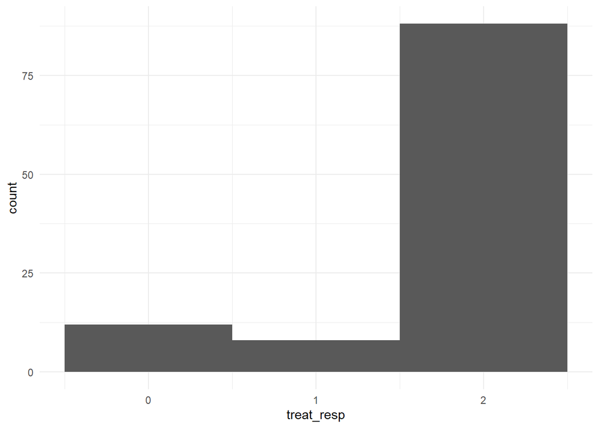

```r
divide_by_treat_resp <- data_filtered %>%
  filter(visit %in% c('1', '2')) %>%
  group_by(id) %>%
  mutate(
    percentage_change = ((as.numeric(`Total score PANSS`[visit == '1']) - as.numeric(`Total score PANSS`[visit == '2'])) / as.numeric(`Total score PANSS`[visit == '1'])) * 100
  ) %>%
  ungroup()

divide_by_treat_resp <- divide_by_treat_resp %>%
  mutate(
  treat_resp = case_when(
    percentage_change < 15 ~ 0, # неответившие на терапию
    percentage_change >= 15 & percentage_change <= 20 ~ 1, # с недостаточным ответом
    percentage_change > 20 ~ 2, # ответившие на терапию
    TRUE ~ NA_real_
  )
)
divide_by_treat_resp %>%
  ggplot() +
  aes(treat_resp) +
  geom_histogram(binwidth = 1) +
  theme_minimal()
```

### Модели с добавлением ответа на терапию

Без разбития на визиты

```r
selected_data <- divide_by_treat_resp %>%
  select(-id) %>%
  select(-excitment, -cognitive, -depression,
         -starts_with('N'), -starts_with('P'), -starts_with('G'), -starts_with('Z'), gender, gait) %>%
  select(-`Verbal Memory`, -`Digit Sequencing`,
         -`Token Motor Task`, -`Verbal Fluency`, -`Symbol Coding`, -`Tower of London`)

lm(`Comp Z` ~ ., data=selected_data) %>%
  step(trace=0) %>% summary()
```

```
##
## Call:
## lm(formula = `Comp Z` ~ age + `disease duration` + antipsychotic +
##     `antipsychotic dose` + `THF dose` + course + education +
##     smoke + visit + `arm dropping` + `wrist rigidity` + tremor +
##     salivation + `Total score PANSS` + CPZE + treat_resp + gait,
##     data = selected_data)
##
## Residuals:
##      Min       1Q   Median       3Q      Max
## -11.7527  -2.9859   0.1838   2.6080  10.2888
##
## Coefficients: (2 not defined because of singularities)
##                                                 Estimate Std. Error t value
## (Intercept)                                     88.39764   15.43559   5.727
## age                                             -0.28693    0.11643  -2.464
## `disease duration`                              -0.32399    0.17829  -1.817
## antipsychoticгалоперидол                        27.59495    9.69724   2.846
## antipsychoticзуклопентиксол                     -8.28586    6.37755  -1.299
## antipsychoticкарипразин                        -43.20726   12.88174  -3.354
## antipsychoticкветиапин                         -36.03680    8.52554  -4.227
## antipsychoticоланзапин                           6.51547    6.24353   1.044
## antipsychoticпалиперидон                       -58.93635   16.26590  -3.623
## antipsychoticрисперидон                        -45.13294   12.97673  -3.478
## antipsychoticтрифлуоперазин                    -18.31598    6.04362  -3.031
## antipsychoticфлупентиксол                       42.92306   11.40974   3.762
## `antipsychotic dose`2                          -11.60789    8.58157  -1.353
## `antipsychotic dose`3                           -6.23879    6.37961  -0.978
## `antipsychotic dose`4                           -0.28236    8.03743  -0.035
## `antipsychotic dose`4.5                         -6.70854    6.60501  -1.016
## `antipsychotic dose`5                          -63.99200   17.66584  -3.622
## `antipsychotic dose`6                           -1.34520    8.47772  -0.159
## `antipsychotic dose`9                            8.88953   14.38334   0.618
## `antipsychotic dose`10                         -52.40706   11.20736  -4.676
## `antipsychotic dose`15                         -25.09491    9.34150  -2.686
## `antipsychotic dose`20                         -38.70638    8.50779  -4.550
## `antipsychotic dose`30                         -29.27984    5.82890  -5.023
## `antipsychotic dose`40                                NA         NA      NA
## `antipsychotic dose`50                         -15.93699   11.98494  -1.330
## `antipsychotic dose`75                          -1.41648   12.32575  -0.115
```

[output cut: 64 more lines]

```
## tremor                                         0.000710 ***
## salivation                                     0.058031 .
## `Total score PANSS`                            0.024844 *
## CPZE                                           0.005795 **
## treat_resp                                     0.009433 **
## gait1                                          0.078929 .
## gait2                                          0.980113
## gait3                                          0.611573
## gait4                                          0.455346
## ---
## Signif. codes:  0 '***' 0.001 '**' 0.01 '*' 0.05 '.' 0.1 ' ' 1
##
## Residual standard error: 5.291 on 61 degrees of freedom
## Multiple R-squared:  0.8356, Adjusted R-squared:  0.7116
## F-statistic: 6.739 on 46 and 61 DF,  p-value: 9.639e-12
```

visit = 1

```r
selected_data <- divide_by_treat_resp %>%
  filter(visit == 1) %>%
  select(-id, -visit) %>%
  select(-excitment, -cognitive, -depression,
         -starts_with('N'), -starts_with('P'), -starts_with('G'), -starts_with('Z'), gender, gait) %>%
  select(-`Verbal Memory`, -`Digit Sequencing`,
         -`Token Motor Task`, -`Verbal Fluency`, -`Symbol Coding`, -`Tower of London`)

lm(`Comp Z` ~ ., data=selected_data) %>%
  step(trace=0) %>% summary()
```

```
##
## Call:
## lm(formula = `Comp Z` ~ `disease duration` + antipsychotic +
##     `antipsychotic dose` + course + education + smoke + `arm dropping` +
##     `shoulder shaking` + `elbow rigidity` + `wrist rigidity` +
##     `head rotation` + tremor + salivation + akathisia + `Total score SAS` +
##     `Total score PANSS` + CPZE + treat_resp + gait, data = selected_data)
##
## Residuals:
##          1          2          3          4          5          6          7
## -1.352e-01 -1.267e+00 -1.892e+00  2.812e+00  3.144e-01  4.172e+00 -7.867e-01
##          8          9         10         11         12         13         14
##  1.065e+00  6.004e-02 -2.532e+00  6.728e-01 -2.551e+00  6.872e-02 -3.144e-01
##         15         16         17         18         19         20         21
##  1.609e+00  1.522e+00 -4.759e+00  1.553e+00  3.881e-01 -1.208e-01 -3.474e-01
##         22         23         24         25         26         27         28
## -2.566e+00 -6.998e-15  3.034e+00  7.403e-01  3.191e+00  2.106e-15 -7.762e-01
##         29         30         31         32         33         34         35
## -1.290e+00 -2.044e+00 -3.707e-01  5.498e-01 -9.472e-16  2.116e-16  3.701e-01
##         36         37         38         39         40         41         42
## -3.701e-01  1.162e-15  6.210e-16 -1.121e-15 -6.748e+00  4.129e+00 -2.671e-16
##         43         44         45         46         47         48         49
##  2.619e+00  1.214e-16  5.204e-17  2.268e+00  4.857e-16  8.854e-01  3.207e-01
##         50         51         52         53         54
## -3.207e-01 -2.268e+00 -8.854e-01  1.023e-15  2.047e-16
##
## Coefficients: (2 not defined because of singularities)
##                                                Estimate Std. Error t value
## (Intercept)                                     55.3026    31.6154   1.749
## `disease duration`                              -0.7029     0.3243  -2.167
## antipsychoticгалоперидол                         8.5664    21.1933   0.404
## antipsychoticзуклопентиксол                     25.5068    13.8773   1.838
## antipsychoticкарипразин                        -30.9065    29.9399  -1.032
## antipsychoticкветиапин                         -39.9904    20.7338  -1.929
## antipsychoticоланзапин                         -21.0096    13.5273  -1.553
## antipsychoticпалиперидон                       -33.5573    30.2881  -1.108
## antipsychoticрисперидон                        -60.9302    30.0542  -2.027
## antipsychoticтрифлуоперазин                      5.5823    17.0706   0.327
## antipsychoticфлупентиксол                        7.9187    24.7869   0.319
## `antipsychotic dose`2                           54.4824    20.1263   2.707
```

[output cut: 82 more lines]

```
## akathisia                                        0.5373
## `Total score SAS`                                0.1921
## `Total score PANSS`                              0.6120
## CPZE                                             0.6128
## treat_resp                                       0.0553 .
## gait1                                            0.0109 *
## gait2                                            0.1189
## gait3                                            0.0803 .
## gait4                                            0.8372
## ---
## Signif. codes:  0 '***' 0.001 '**' 0.01 '*' 0.05 '.' 0.1 ' ' 1
##
## Residual standard error: 6.185 on 5 degrees of freedom
## Multiple R-squared:  0.9641, Adjusted R-squared:  0.6197
## F-statistic: 2.799 on 48 and 5 DF,  p-value: 0.125
```

visit = 2

```r
selected_data <- divide_by_treat_resp %>%
  filter(visit == 2) %>%
  select(-id, -visit) %>%
  select(-excitment, -cognitive, -depression,
         -starts_with('N'), -starts_with('P'), -starts_with('G'), -starts_with('Z'), gender, gait) %>%
  select(-`Verbal Memory`, -`Digit Sequencing`,
         -`Token Motor Task`, -`Verbal Fluency`, -`Symbol Coding`, -`Tower of London`)

sum <- lm(`Comp Z` ~ ., data=selected_data) %>%
  step(trace=0) %>% summary()
```

lm с помощью Shiny можно запустить.

Для обоих визитов:

```r
path <- here("scripts/1_eda", "lm_shiny.R")
source(path)
lm_shiny(data_filtered %>% select(!matches("P\\d{1}") & !matches("N\\d{1}") & !matches("G\\d{1}") & !id))
```

Для разницы между визитами:

```r
path <- here("scripts/1_eda", "lm_shiny.R")
source(path)
lm_shiny(difference_df %>% select(!matches("P\\d{1}") & !matches("N\\d{1}") & !matches("G\\d{1}") & !id))
```